# Modelos de Umbral

jack

8/7/2020

# Modelos de Umbral

Modelar **por bloques** como asume GEV hace **uso poco eficiente de los datos** de existir un grado ‘más fino’ de valores históricos máximos (ej: máxima diaria)

Al elegir un único máximo por cada bloque, perdemos la oportunidad de capturar cualquier otro máximo similar en el mismo bloque, o inyectamos valores poco informativos para bloques sin máximos relevantes.

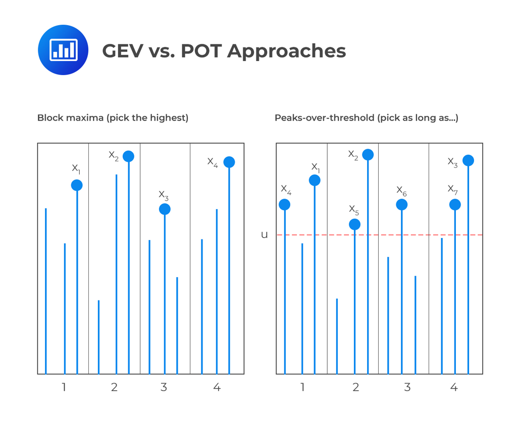

gev-vs-pot

Formalmente,

Sean $\normalsize X_1, X_2, \dots , X_m$ una secuencia de variables aleatorias independientes e identicamente distribuídas, con distribución $\normalsize X_1 \sim F$

Podemos definir a la distribución de los valores extremos como:

$$\large P\left( X_i > u + y \ |\ X > u \right) = \frac {1 - F(u + y)}{1-F(u)}$$

Notar que el cociente es simplemente la relación entre el **area a derecha de un valor $\normalsize y$ por encima del umbral**, dividido por el **área a derecha del umbral** $\normalsize u$ para la densidad de $\normalsize F$

Solo bastaría conocer $\normalsize F$ para calcular la distribución de excesos.

En general, $\normalsize F$ es una distribución **no conocida** que debemos aproximar a partir de los datos.

# Modelos Asintóticos:

## Distribución Pareto Generalizada (GPD)

Asumiendo las mismas hipótesis que en GEV, la distribución de excesos por sobre un umbral $\normalsize u$, está dada por:

$$\Large H_{\sigma,\xi}(y) =
\begin{cases}
1 - \left( 1 + \frac{\xi}{\sigma} \ y \right)^{- \frac 1 \xi}, & \text{si}\ \ \xi \neq 0 \\
1 - e^{- \frac y \sigma}, & \text{si}\ \ \xi = 0
\end{cases}$$

> con $\normalsize y > 0$, valor por encima el umbral.

$\normalsize \xi$, llamado *parámetro de forma*, mantiene el mismo valor al ajustar los parámetros con GEV, y en ambos casos se cumple que:

> Si $\normalsize \xi < 0$: * la distribución de excesos tiene **cota superior** dada por: $\normalsize u - \frac \sigma \xi$

> Si $\normalsize \xi > 0$: * la distribución de excesos **no tiene cota superior**.

> Si $\normalsize \xi = 0$: * la distribución de excesos **no tiene cota superior** y se reduce a una distribución $\normalsize \text{Exponencial}\left(\frac 1 \sigma \right)$

### Ejemplo:

Volviendo a la distribución de valores extremos de la primera parte y si elegimos $F$ como Exponencial

Entonces:

$$\large \begin{align}
P\left( X_i > u + y \ |\ X > u \right) &= \frac {1 - F(u + y)}{1-F(u)}\\\\
&= \frac {e^{-(u+y)}}{e^{-u}}\\\\
&= e^{-y}
\end{align}$$

De forma que la distribución de extremos de las variables aleatorias Xi con distribución exponencial, es a su vez exponencial, lo que se explica también por la [**propiedad de pérdida de memoria** de la distribución Exponencial](https://en.wikipedia.org/wiki/Memorylessness).

~